# Torque The Talk, Bike The Bike

Harriet Brookes-Gray, Ellen Dong, Christina Hung

April 27, 2019

```r
knitr::opts_chunk$set(echo = TRUE)
#Opening the libraries, getting scidb data

library(tidyverse)
library(RMySQL)
library(leaflet)
library(sf)
library(dplyr)
library(ggplot2)
library(scales)

db <- dbConnect(MySQL(),
                host = "scidb.smith.edu",
                user = "mth292",
                password = "RememberPi",
                dbname = "citibike")
knitr::opts_chunk$set(connection = db, max.print = 20)
```

GitHub Repository[^1]

[figure not shown]

Citi Bikes in NYC

```r
#SQL Query to Join the Tables

dbGetQuery (db,
            "SELECT station_id, name, avg_lat, avg_lon
            FROM trips
            LEFT JOIN station_months ON trips.start_station_id = station_months.station_id
            WHERE start_time > '2017-01-01 06:00:00' AND stop_time < '2017-01-01 10:00:00'
            GROUP BY station_id
            ORDER BY start_time;")
```

```r
#SQL Query to Count Unique Bikes (uses bike_id key/index)

dbGetQuery (db,
            "SELECT COUNT(DISTINCT bike_id) AS number_of_bikes
            FROM trips;")
```

```r
#SQL query to find young subscribers and moving it into R

young_subscribers <- dbGetQuery(db,
                    "SELECT user_type, COUNT(user_type) AS number_of_users, birth_year
                    FROM trips
                    WHERE user_type = 'subscriber'
                    AND birth_year > 1980
                    GROUP BY birth_year
                    ORDER BY birth_year DESC;")
```

```r
#Plotting proportion of young subscribers

young_subscribers_plot <- ggplot(young_subscribers, aes(x = birth_year, y = number_of_users))
```

```r
#SQL query to find old subscribers and moving it into R

old_subscribers <- dbGetQuery(db,
                     "SELECT user_type, COUNT(user_type) AS number_of_users, birth_year
                      FROM trips
                      WHERE user_type = 'subscriber'
                      AND birth_year < 1980
                      GROUP BY birth_year
                      ORDER BY birth_year DESC;")
```

```r
#creating table for determining the gender of the subscribers

gender_subscribers <- dbGetQuery(db,
                     "SELECT user_type, COUNT(user_type) AS number_of_subscribers, gender
                      FROM trips
                      WHERE user_type = 'subscriber'
                      AND birth_year BETWEEN 1945 AND 2001
                      AND start_time > '2017-01-01 06:00:00' AND stop_time < '2017-01-01 10:00:00'
                      GROUP BY gender;")
```

As one of the largest cities in the United States, New York City faces a problem of congestion on its roads. However, one increasingly popular alternative mode of transportation is bicycles. Evidence lies in New York’s most popular bike sharing system, Citi Bike, that has rapidly expanded over the last four years. In July of 2017, Citi Bike reported that they had 130,000 annual subscribers. By October 2017, they had reached a total of 50 million rides since launching in May 2013, averaging out to 31,000 bikes rides per day[^2]. Does this increase in popularity suggest that bike sharing is a promising transportation alternative in New York City?

Citi Bike is [one of the largest bike sharing systems in the country.](https://www.citibikenyc.com/how-it-works) They currently claim to have 12,000 bikes and 750 stations across Manhattan, Brooklyn, Queens, and Jersey City. According to their website, these bikes are designed for “quick trips with convenience in mind,” and are a “fun and affordable way to get around town.” Customers can check out a bike from any one of their stations, use it, and then return it when they’re done.

However, Citi Bikes sound better in theory than in practice. [A 2018 article by Streetsblog NYC](https://nyc.streetsblog.org/2018/09/26/its-not-your-imagination-something-is-seriously-wrong-with-citi-bike-right-now/) reveals that Citi Bike is having issues maintaining their bikes, meaning that only three-quarters of their stated number of bikes are actually available to customers. Citi Bike is also not subsidized by New York City, which may contribute to their difficulties in keeping a sufficient number of bikes in working condition. As if that wasn’t enough, [a 2017 article from Bklyner](https://bklyner.com/citi-bike-thefts-rise-due-improper-docking-cops-warn/) talks about how Citi Bikes are being stolen if they are not docked properly, which can lead the customer to being charged $1,200.

> Given all of this, who uses Citi Bikes? Are they a useful mode of everyday transportation for New Yorkers?

To investigate this question, we analyzed the Citi Bike data from 2017 that captures information on two types of Citi Bike users: customers and subscribers. The type of user can be interpreted as an indicator of who is using the Citi Bikes, since ‘customers’ can only purchase a 24-hour or 3-day pass, while a subscriber can purchase an annual membership. The difference in purchasing options for each user suggests that customers are more likely to be tourists while subscribers are more likely to be NYC residents. We used this data to compare two plots between customers and subscribers.

```r
#SQL query to count number of subscribers

count_subscribers <- dbGetQuery(db,
                          "SELECT birth_year, COUNT(user_type) AS total_number_of_subscribers
                            FROM trips
                            WHERE user_type = 'subscriber'
AND birth_year >=1945
                           GROUP BY birth_year;")
```

```r
#SQL query to count number of customers

count_customers <- dbGetQuery(db,
                            "SELECT birth_year, COUNT(user_type) AS total_number_of_customers
                            FROM trips
                            WHERE user_type = 'customer' AND birth_year >= 1945
                            GROUP BY birth_year;")
```

```r
#Joining the tables that count subscribers and customers

total_users <- count_subscribers %>% full_join(count_customers)
```

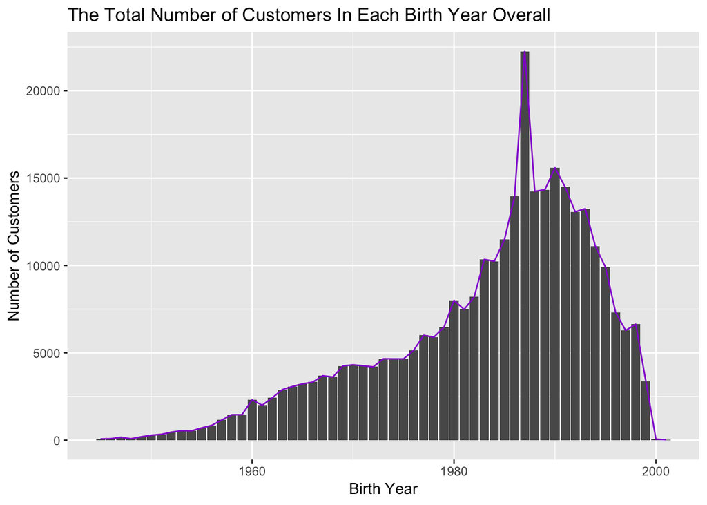

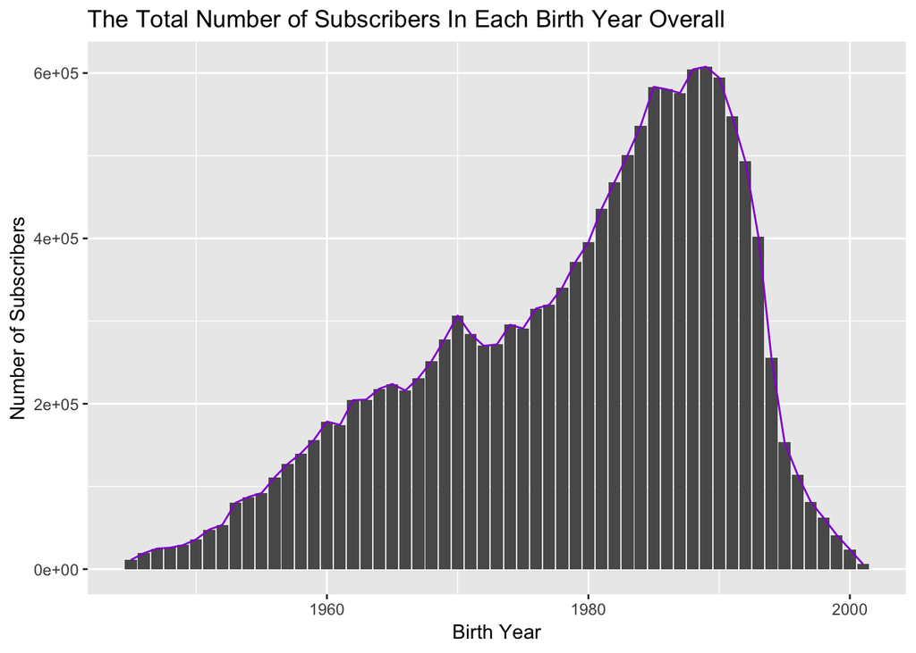

```r
#Plotting subscribers vs. customers

subs_vs_cus <- ggplot(data = total_users, aes(x = birth_year, y = total_number_of_customers)) +
  geom_col() +
  geom_line(aes(color = "plum4")) +
  scale_color_manual(values = c("darkviolet")) +
  labs(title = "The Total Number of Customers In Each Birth Year Overall",
       x = "Birth Year",
       y = "Number of Customers") +
  theme(legend.position = "none")


subs_vs_cus2 <- ggplot(data = total_users, aes(x = birth_year, y = total_number_of_subscribers)) +
  geom_col() +
  geom_line(aes(color = "plum4")) +
  scale_color_manual(values = c("darkviolet")) +
  labs(title = "The Total Number of Subscribers In Each Birth Year Overall",
       x = "Birth Year",
       y = "Number of Subscribers") +
  theme(legend.position = "none")

subs_vs_cus
subs_vs_cus2
```

The number of users of the Citi Bikes within 2017 appears overwhelmingly to be subscribers rather than customers. This evidence is in line with the New York Department of Transportation’s report that [49% of New Yorkers](https://www.bicycling.com/culture/a23676188/best-bike-cities-2018/) say they ride a bike at least a few times a month. Most importantly, this evidence suggests that bikes are widely used among New Yorker as a mode of transport. Therefore, New York City policy makers should consider bike sharing as a serious alternative mode of transport within the city.

The search for alternative modes of transport for NYC residents is becoming increasingly important as NYC roles out their [congestion tax](https://www.nytimes.com/2019/03/26/nyregion/what-is-congestion-pricing.html) on vehicles traveling into or within Manhattan. The plan is to utilize the tax revenues from this congestion pricing to improve the subway system. This evidence from Citi Bike suggests that bike sharing may also be a worthy alternative in to which these revenues could be funneled.

```r
#SQL query to get top 5 stations by most subscribers into R (using indexes)

most_subscribers_gg <- dbGetQuery(db,
                            "SELECT birth_year, COUNT(user_type) AS total_number_of_subscribers, start_station_id, station_months.name, start_time, trips.stop_time, station_id, avg_lat, avg_lon
                            FROM trips
                            LEFT JOIN station_months ON trips.start_station_id = station_months.station_id
                            WHERE user_type = 'subscriber'
                            AND start_time > '2017-01-01 06:00:00' AND stop_time < '2017-01-01 10:00:00'
                            AND birth_year >= 1945
                            GROUP BY birth_year
                            ORDER BY total_number_of_subscribers DESC;")
```

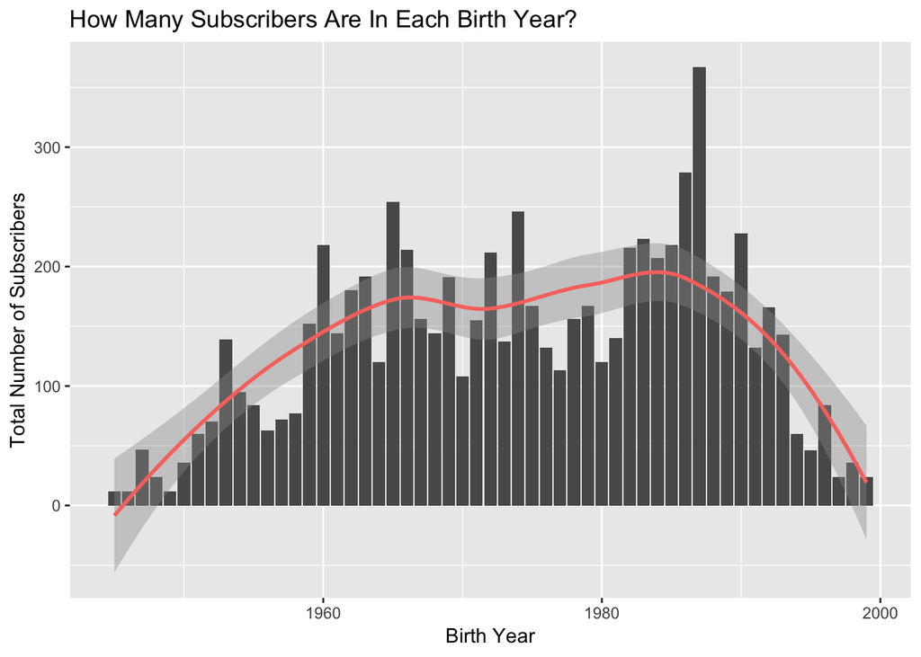

```r
#Plotting number of subscribers per birth year

most_subscribers_ggplot <- ggplot(most_subscribers_gg, aes(x = birth_year, y = total_number_of_subscribers)) +
  geom_col() +
  geom_smooth(aes(color = "red")) +
  labs(title = "How Many Subscribers Are In Each Birth Year?",
       x = "Birth Year",
       y = "Total Number of Subscribers") +
  theme(legend.position = "none")

most_subscribers_ggplot
```

However, it could be argued that bike sharing may not be a worthy transport alternative in NYC upon looking at a further breakdown of demographics of Citi Bike users. Our second point of analysis was to look at the division in sex among subscribers across all ages. We focused specifically on morning rush hours (6am-10am), as this is when subscribers who use this as an everyday mode of transport would be most active.

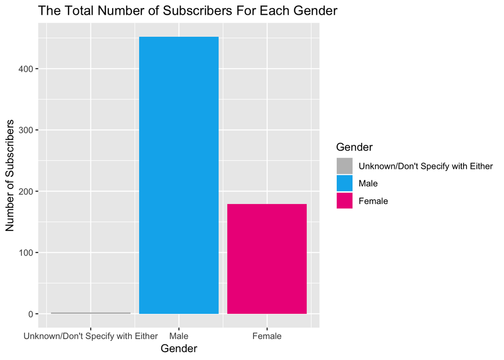

```r
#creating the graph of the gender of the subscribers

cols <- c("0" = "gray", "1" = "deepskyblue2", "2" = "deeppink2")

cols <- c("0" = "gray", "1" = "deepskyblue2", "2" = "deeppink2")

gender_s <- ggplot(data = gender_subscribers, aes(x = gender, y = number_of_subscribers)) +
  geom_col(aes(fill = factor(gender))) +
  labs(title = "The Total Number of Subscribers For Each Gender",
       x = "Gender",
       y = "Number of Subscribers",
       fill = "Gender") +
  scale_x_continuous(breaks = c(0, 1, 2),
                     labels = c("Unknown/Don't Specify with Either", "Male", "Female")) +
  scale_fill_manual(values = cols,
                     limits = c("0", "1", "2"),
                     labels = c("Unknown/Don't Specify with Either", "Male", "Female"))
gender_s
```

```r
#SQL query to find top 5 stations by most subscribers (using indexes)

most_subscribers <- dbGetQuery(db,
                            "SELECT birth_year, COUNT(user_type) AS total_number_of_subscribers, start_station_id, station_months.name, start_time, trips.stop_time, station_id, avg_lat, avg_lon
                            FROM trips
                            LEFT JOIN station_months ON trips.start_station_id = station_months.station_id
                            WHERE user_type = 'subscriber'
                            AND start_time > '2017-01-01 06:00:00' AND stop_time < '2017-01-01 10:00:00'
                            AND birth_year >= 1945
                            GROUP BY birth_year
                            ORDER BY total_number_of_subscribers DESC
                            LIMIT 5;")
```

```r
#Making leaflet of top 5 stations by subscribers

most_subscribers_plot <- leaflet() %>%
  addTiles() %>%
  addMarkers(data = most_subscribers, lng = ~avg_lon, lat = ~avg_lat, popup = ~name)

most_subscribers_plot
```

[interactive chart not shown]

This evidence may appear to disprove our hypothesis that bike sharing is a promising transport alternative, but it does not detract from our argument for the following reasons. First, Citi Bike could be redesigned to be lighter and smaller, and safety measures could be implemented to make people feel safer. Secondly, Citi Bike is not subsidized by NYC. If it were to be, this would probably lower the annual membership fee and make the bikes more accessible to a wider range of incomes. Thirdly, while many of the stations are clustered in Manhattan, they could be spread out across the city and this would enable them to reach more New Yorkers, making the bikes a more viable alternative.

Overall, we argue that Citi Bikes are potentially a very good alternative transportation system. They are environmentally friendly, health promoting, and as more people use bicycles frequently, the safer it becomes to do so. On the other hand, it seems that bike sharing is concentrated in wealthy areas and overwhelmingly faces males. However, if Citi Bike redesigned their bikes, and if the NYC government subsidized Citi Bike to make them cheaper and spread stations more widely, these problems could be mitigated[^3].

[^1]: https://github.com/Ellen-Yi-Dong/mini_project_4
[^2]: https://en.wikipedia.org/wiki/Citi_Bike
[^3]: https://www.nydailynews.com/news/national/citibike-stalled-article-1.3228521